# FAS1003: Visualisation des données

# Cours 8: Modèles statistiques

## Plan de match

1. Modèles statistiques
2. Un truc pour ajouter les points derrière des graphs
3. Annotations
4. Faire pivoter les données
5. Explications du travail final

# Visualiser les modèles statistiques

## Les données du jour

```r
library(tidyverse)
air <- airquality
```

## Modèle de régression linéaire: Rappels

Démo au tableau.

## Modèle de régression linéaire

Supposons que nous sommes intéressés par le modèle suivant:

```r
modele <- lm(Temp ~ Wind + Solar.R + as.factor(Month), data = air)
```

## Explorer les résultats

```r
summary(modele)
```

```
##
## Call:
## lm(formula = Temp ~ Wind + Solar.R + as.factor(Month), data = air)
##
## Residuals:
##      Min       1Q   Median       3Q      Max
## -12.7987  -4.0036  -0.6883   4.0873  15.7654
##
## Coefficients:
##                    Estimate Std. Error t value Pr(>|t|)
## (Intercept)       70.123209   2.295297  30.551  < 2e-16 ***
## Wind              -0.723387   0.144566  -5.004 1.67e-06 ***
## Solar.R            0.023372   0.005513   4.239 4.06e-05 ***
## as.factor(Month)6 11.958897   1.568042   7.627 3.44e-12 ***
## as.factor(Month)7 15.188732   1.602650   9.477  < 2e-16 ***
## as.factor(Month)8 16.164466   1.626746   9.937  < 2e-16 ***
## as.factor(Month)9 10.227537   1.571535   6.508 1.28e-09 ***
## ---
## Signif. codes:  0 '***' 0.001 '**' 0.01 '*' 0.05 '.' 0.1 ' ' 1
##
## Residual standard error: 5.856 on 139 degrees of freedom
##   (7 observations deleted due to missingness)
## Multiple R-squared:  0.6136, Adjusted R-squared:  0.597
## F-statistic: 36.79 on 6 and 139 DF,  p-value: < 2.2e-16
```

La fonction `summary()` nous montre les résultats de régression sous forme de tableau, avec des colonnes pour les coefficients, les erreurs type, les valeurs t et les statistiques p.

## L’objet `modele`

L’objet `modele` n’est pas organisé sous forme de tableau.

```r
View(modele)
```

## Organiser l’information dans un format `tidy`

- chaque ligne est une observation
- chaque colonne est une variable
- chaque cellule contient une seule valeur

## La fonction `tidy()`

- transforme les résultats de régression sous forme de tableau
- ligne pour les paramètres (variables), colonnes pour les statistiques
- ajout des intervalles de confiance (`conf.int = TRUE`)
- intervalles à 95%.

```r
modele_tab <- tidy(modele, conf.int = TRUE)
modele_tab
```

```
## # A tibble: 7 × 7
##   term              estimate std.error statistic  p.value conf.low conf.high
##   <chr>                <dbl>     <dbl>     <dbl>    <dbl>    <dbl>     <dbl>
## 1 (Intercept)        70.1      2.30        30.6  1.55e-63  65.6      74.7
## 2 Wind               -0.723    0.145       -5.00 1.67e- 6  -1.01     -0.438
## 3 Solar.R             0.0234   0.00551      4.24 4.06e- 5   0.0125    0.0343
## 4 as.factor(Month)6  12.0      1.57         7.63 3.44e-12   8.86     15.1
## 5 as.factor(Month)7  15.2      1.60         9.48 9.62e-17  12.0      18.4
## 6 as.factor(Month)8  16.2      1.63         9.94 6.56e-18  12.9      19.4
## 7 as.factor(Month)9  10.2      1.57         6.51 1.28e- 9   7.12     13.3
```

## Visualiser

- Une fois les informations de notre modèle “nettoyées”, nous pouvons nous en servir pour présenter les résultats de régression sous forme de graphique.

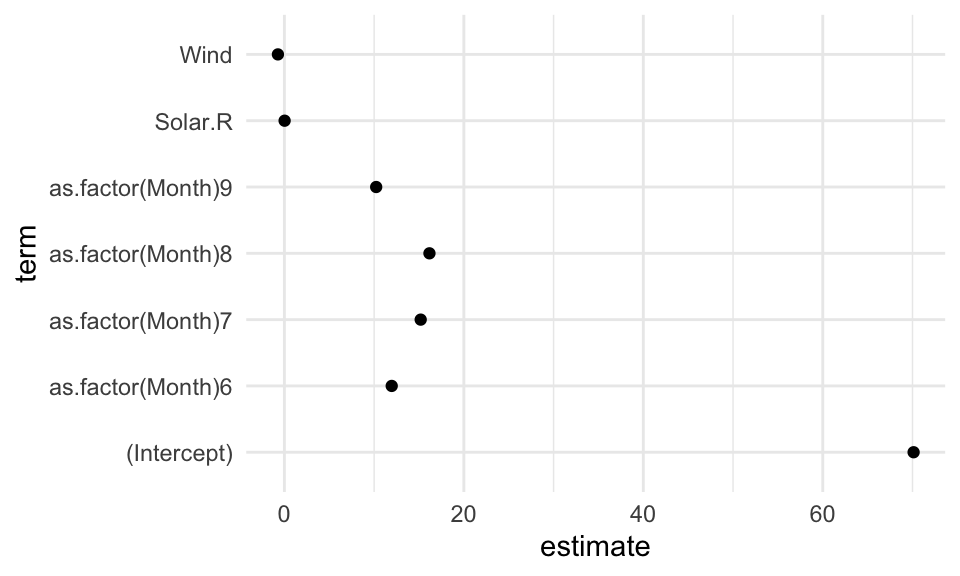

```r
graph_mod <- ggplot(aes(y = term,
                        x = estimate),
                    data = modele_tab) +
  geom_point() +
  theme_minimal()

graph_mod
```

## Enlever des coefficients

- La constante (intercept) ne m’intéresse pas.
- Vu que nos résultats de régression sont organisés sous forme de tableau, il est plutôt simple de faire des modifications.

```r
modele_tab2 <- modele_tab  %>%
  filter(!str_detect(term, "Intercept")) %>%
  mutate(term = case_when(str_detect(term, "Solar")~"Solaire (rad.)",
                          str_detect(term, "Wind")~"Vent (vitesse)",
                          str_detect(term, "9")~"Sept.",
                          str_detect(term, "8")~"Août",
                          str_detect(term, "7")~"Juil.",
                          str_detect(term, "6")~"Juin",
                          TRUE~term))
```

## Modifier notre graphique

- J’aimerais que les noms de variables soient à l’horizontal (sur l’axe des y);
- J’aimerais avoir un point pour le coefficient estimé par le modèle, et une ligne qui traverse le point pour montrer l’intervalle de confiance;
- J’aimerais avoir une ligne verticale à 0, pour montrer quels estimés ne sont pas statistiquement significatifs.

## Modifier notre graphique

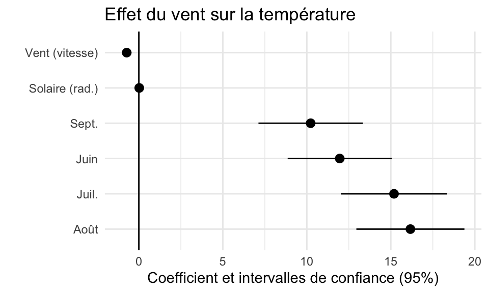

```r
graph_mod <- ggplot(aes(y = term, x = estimate,
                        xmin = conf.low, xmax = conf.high),
                    data = modele_tab2) +
  geom_pointrange() +
  geom_vline(xintercept = 0) +
  labs(title = "Effet du vent sur la température",
       y = "",
       x = "Coefficient et intervalles de confiance (95%)") +
  theme_minimal()

graph_mod
```

## Visualiser des prédictions

- Il est possible de créer des prédictions pour des observations fictives à partir de notre modèle de régression.
- Voir: http://www.sthda.com/english/articles/40-regression-analysis/166-predict-in-r-model-predictions-and-confidence-intervals/
- Voir le chapitre 6 de Healy: https://socviz.co/modeling.html#modeling

## Visualiser des prédictions: créer des observations fictives

- Nous allons créer une fausse banque de données avec 2500 observations (vs 153 pour la banque de données `air`).
- Nous générons 500 valeurs situées entre le minimum (1.7) et le maximum (20.7) de la variable `Wind`.
- Ces 500 valeurs sont associées à chacun des 5 mois du modèle (5 à 9, ou mai, juin, juillet, août, septembre), ce qui crée les 2500 observations.
- Toutes les observations ont la même valeur pour la variable `Solar.R` (fixée à la moyenne).

## Visualiser des prédictions: créer des observations fictives

- Il serait possible, bien sûr, de créer des fausses observations plus grandes ou plus petites que la vraie étendue de la variable `Wind` (1.7 à 20.7).
- Or, nos prédictions ne seraient alors pas réalistes.
- Il est donc préférable de s’en tenir aux valeurs “possibles”.

## Visualiser des prédictions: créer des observations fictives

```r
air_pred <- expand.grid(Wind = (seq(from = min(air$Wind),
                                   to = max(air$Wind),
                                   length.out = 500)),
                        Solar.R = mean(air$Solar.R, na.rm = T),
                        Month = c(5:9))

head(air_pred)
```

```
##       Wind  Solar.R Month
## 1 1.700000 185.9315     5
## 2 1.738076 185.9315     5
## 3 1.776152 185.9315     5
## 4 1.814228 185.9315     5
## 5 1.852305 185.9315     5
## 6 1.890381 185.9315     5
```

## Visualiser des prédictions: Prédire des résultats pour nos observations fictives

- On utilise ensuite la fonction `predict()` pour trouver quelle valeur de Y (`Temp`) est prédite (`fit`) par notre modèle pour chaque valeur de la variabe X (`Wind`).
- J’en profite pour convertir le résultat en tableau de données avec `as.data.frame`.

```r
predictions <- predict(object = modele,
                       newdata = air_pred,
                       interval = "predict") %>%
  as.data.frame()
```

## Visualiser des prédictions: Prédire des résultats pour nos observations fictives

- `predict()` calcule aussi l’intervalle de confiance autour de chaque prédiction (`lwr` et `upr`)
- Nous allons joindre ces prédictions au tableau de données fictives créé plus tôt.

## Visualiser des prédictions: Prédire des résultats pour nos observations fictives

```r
prediction_viz <- cbind(air_pred, predictions)

head(prediction_viz)
```

```
##       Wind  Solar.R Month      fit      lwr      upr
## 1 1.700000 185.9315     5 73.23913 61.10554 85.37272
## 2 1.738076 185.9315     5 73.21158 61.08056 85.34261
## 3 1.776152 185.9315     5 73.18404 61.05556 85.31252
## 4 1.814228 185.9315     5 73.15650 61.03056 85.28243
## 5 1.852305 185.9315     5 73.12895 61.00555 85.25236
## 6 1.890381 185.9315     5 73.10141 60.98053 85.22229
```

## Visualiser des prédictions: Faire le graph

- Nous visualisons les températures prédites par notre modèle pour différentes valeurs de la vitesse du vent.
- Les prédictions ont été calculées en gardant le niveau de radiation solaire constant (à sa moyenne).
- Les prédictions sont calculées pour chaque mois.

## Visualiser des prédictions: Faire le graph

```r
graph_pred <- ggplot(aes(x = Wind, y = fit,
                         ymin = lwr, ymax = upr),
                     data = prediction_viz) +
# lignes de prédiction (5 couleurs)
  geom_line(aes(color = as.factor(Month))) +
# geom_ribbon ajoute l'intervalle de confiance
# (une par mois, c'est pourquoi on précise "group")
  geom_ribbon(aes(group = as.factor(Month)), alpha = .1) +
  scale_color_discrete(name = "Mois",
                      labels = c("Mai", "Juin", "Juillet",
                                 "Août", "Septembre")) +
  labs(title = "Température prédite en fonction du vent",
       y = "Température prédite\n(avec intervalle de 95%)",
       x = "Vitesse du vent") +
  theme_minimal()
```

## Visualiser des prédictions: Faire le graph

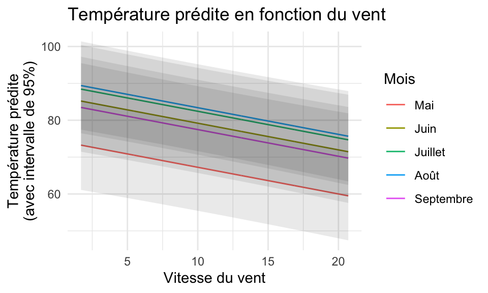

```r
graph_pred
```

## Visualiser des prédictions: Montrer les vraies observations

- Nous pourrions aussi faire apparaître les vraies observations derrière les lignes de prédiction.
- Pour ce faire, j’ajoute un étage `geom_point` qui utilise les données de la banque de données originales, et non la banque de données fictives.

## Visualiser des prédictions: Montrer les vraies observations

```r
graph_pred2 <- ggplot() +
  geom_point(data = air,
             aes(x = Wind, y = Temp,
                 color =  as.factor(Month)),
             alpha = .6) +
  geom_line(data = prediction_viz,
            aes(x = Wind, y = fit,
                color = as.factor(Month))) +
  geom_ribbon(data = prediction_viz,
              aes(x = Wind, y = fit,
                  ymin = lwr, ymax = upr,
                  group = as.factor(Month)),
              alpha = .1) +
  scale_color_discrete(name = "Mois",
                      labels = c("Mai", "Juin", "Juillet",
                                 "Août", "Septembre")) +
  labs(title = "Température en fonction du vent",
       y = "Température prédite\n(avec intervalle de 95%)",
       x = "Vitesse du vent") +
  theme_minimal()
```

## Visualiser des prédictions: Montrer les vraies observations

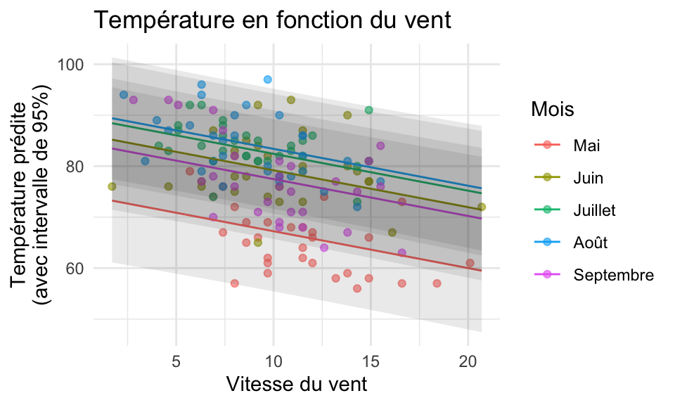

```r
graph_pred2
```

## Visualiser des prédictions: Montrer les vraies observations

1. J’ai sécifié une fonction `ggplot` vide;
2. J’ai tracé les points originaux, par couleur de mois (`geom_point`);
3. J’ai tracé les lignes de valeurs prédites, par couleur de mois (`geom_line`);
4. J’ai tracé les intervalles de confiance (`geom_ribbon`).

# Pause

# Quelques manipulations de plus

## Faire la gigue: jitter

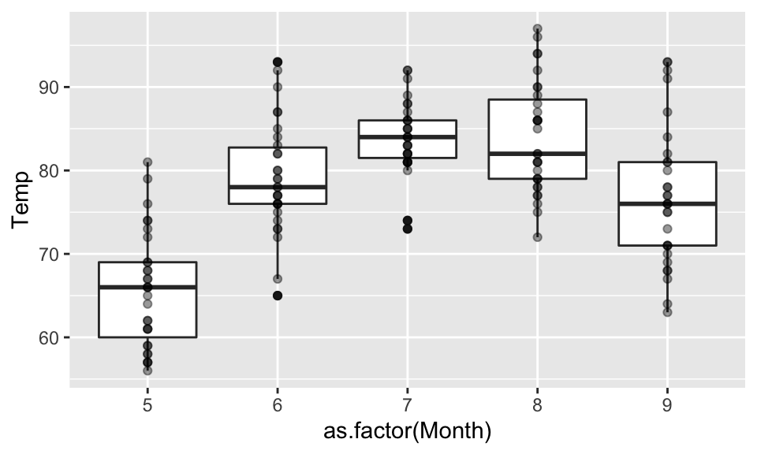

```r
p = ggplot(data = air, aes(x = as.factor(Month), y = Temp)) +
  geom_boxplot()

p + geom_point(alpha = .4)
```

## Faire la gigue: jitter

Déplacer un peu des points, à l’horizontale et à la verticale.

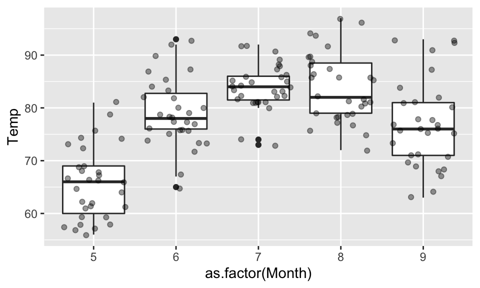

```r
p + geom_jitter(alpha = .4) # width = 0.2
```

## Inclure des annotations: annotate

- Spécifier le type d’élément à inclure: du texte sur le graph, des lignes, des rectangles, des flèches, etc.
- Spécifier sa locatisation

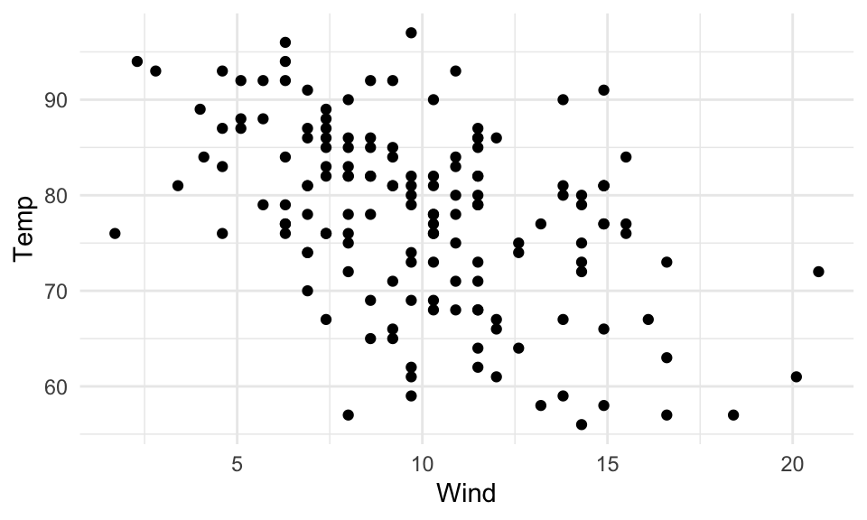

```r
p = ggplot(data = air, aes(x = Wind, y = Temp)) +
  geom_point() +
  theme_minimal()

p
```

## Inclure des annotations: annotate

Des encadrés (`rect`)

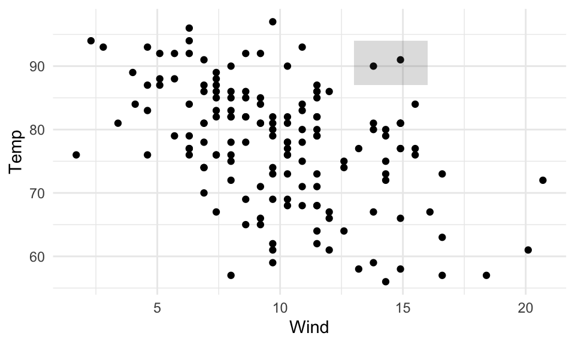

```r
p + annotate("rect",
             xmin = 13, xmax = 16,
             ymin = 87, ymax = 94,
             alpha = .2)
```

## Inclure des annotations: annotate

Des traits (`segment`)

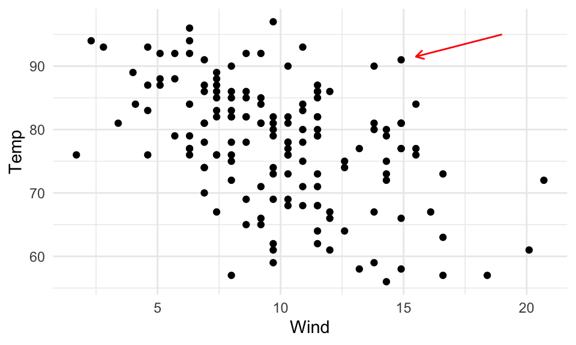

```r
p + annotate("segment",
             x = 19, xend = 15.5,
             y = 95, yend = 91.5,
             color = "red",
             arrow = arrow(length = unit(.2,"cm")))
```

## Inclure des annotations: annotate

Du texte (`text`)

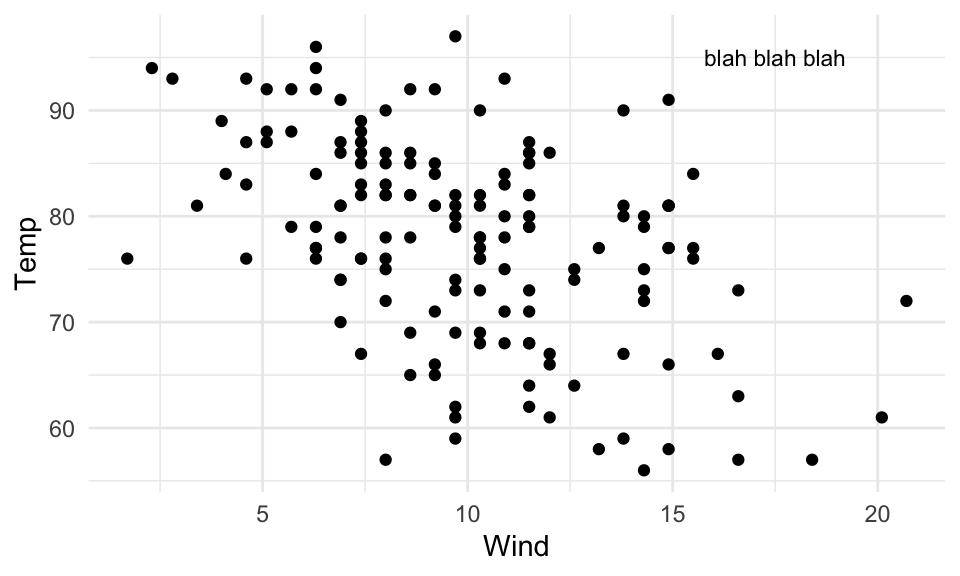

```r
p + annotate("text",
             x = 17.5,
             y = 95,
             label = "blah blah blah",
             size = 3)
```

## Faire pivoter la banque de données

- Une banque de données peut être organisée dans un format “long” ou dans un format “large”
- Exemple au tableau

```r
dat = data.frame(personne = c("A", "B", "C", "D"),
                 avant  = c(150, 115, 160, 133),
                 apres = c(152, 111, 161, 140))
```

## Faire pivoter la banque de données: pivot_longer

Transformer au format “long”

```r
# de la variable "avant" à la variable "apres"
dat_long = dat %>%
  pivot_longer(avant:apres,
               names_to = "timing",
               values_to = "mesure")
```

## Faire pivoter la banque de données: pivot_longer

Transformer au format “long”

```r
# toutes les variables sauf "personne"
dat_long = dat %>%
  pivot_longer(!personne,
               names_to = "timing",
               values_to = "mesure")
```

## Faire pivoter la banque de données: pivot_wider

Transformer au format “large”

```r
dat_large = dat_long %>%
  pivot_wider(names_from = timing,
              values_from = mesure)
```

# Pause

# Exercice de visualisation 2